# Bike Demand Prediction Notes

## Problem Statement

You are provided hourly rental data spanning two years. For this competition, the training set is comprised of the first 19 days of each month, while the test set is the 20th to the end of the month. You must predict the total count of bikes rented during each hour covered by the test set, using only information available prior to the rental period.

## Data Fields

- **datetime** hourly date + timestamp
- **season**
  - 1 = spring
  - 2 = summer
  - 3 = fall
  - 4 = winter
- **holiday** whether the day is considered a holiday
- **workingday** whether the day is neither a weekend nor holiday
- **weather**
  - 1: Clear, Few clouds, Partly cloudy, Partly cloudy
  - 2: Mist + Cloudy, Mist + Broken clouds, Mist + Few clouds, Mist
  - 3: Light Snow, Light Rain + Thunderstorm + Scattered clouds, Light Rain + Scattered clouds
  - 4: Heavy Rain + Ice Pallets + Thunderstorm + Mist, Snow + Fog
- **temp** - temperature in Celsius
- **atemp** - “feels like” temperature in Celsius
- **humidity** - relative humidity
- **windspeed** - wind speed
- **casual** - number of non-registered user rentals initiated
- **registered** - number of registered user rentals initiated
- **count** - number of total rentals

## Workspace

Loading the training data set

```r
data.train = read.csv('data\\train.csv')
summary(data.train)
```

```
##                 datetime         season        holiday
##  2011-01-01 00:00:00:    1   Min.   :1.00   Min.   :0.0000
##  2011-01-01 01:00:00:    1   1st Qu.:2.00   1st Qu.:0.0000
##  2011-01-01 02:00:00:    1   Median :3.00   Median :0.0000
##  2011-01-01 03:00:00:    1   Mean   :2.51   Mean   :0.0286
##  2011-01-01 04:00:00:    1   3rd Qu.:4.00   3rd Qu.:0.0000
##  2011-01-01 05:00:00:    1   Max.   :4.00   Max.   :1.0000
##  (Other)            :10880
##    workingday       weather          temp           atemp
##  Min.   :0.000   Min.   :1.00   Min.   : 0.82   Min.   : 0.76
##  1st Qu.:0.000   1st Qu.:1.00   1st Qu.:13.94   1st Qu.:16.66
##  Median :1.000   Median :1.00   Median :20.50   Median :24.24
##  Mean   :0.681   Mean   :1.42   Mean   :20.23   Mean   :23.66
##  3rd Qu.:1.000   3rd Qu.:2.00   3rd Qu.:26.24   3rd Qu.:31.06
##  Max.   :1.000   Max.   :4.00   Max.   :41.00   Max.   :45.45
##
##     humidity       windspeed        casual      registered      count
##  Min.   :  0.0   Min.   : 0.0   Min.   :  0   Min.   :  0   Min.   :  1
##  1st Qu.: 47.0   1st Qu.: 7.0   1st Qu.:  4   1st Qu.: 36   1st Qu.: 42
##  Median : 62.0   Median :13.0   Median : 17   Median :118   Median :145
##  Mean   : 61.9   Mean   :12.8   Mean   : 36   Mean   :156   Mean   :192
##  3rd Qu.: 77.0   3rd Qu.:17.0   3rd Qu.: 49   3rd Qu.:222   3rd Qu.:284
##  Max.   :100.0   Max.   :57.0   Max.   :367   Max.   :886   Max.   :977
##
```

```r
data.test = read.csv('data\\test.csv')
summary(data.test)
```

```
##                 datetime        season        holiday
##  2011-01-20 00:00:00:   1   Min.   :1.00   Min.   :0.0000
##  2011-01-20 01:00:00:   1   1st Qu.:2.00   1st Qu.:0.0000
##  2011-01-20 02:00:00:   1   Median :3.00   Median :0.0000
##  2011-01-20 03:00:00:   1   Mean   :2.49   Mean   :0.0291
##  2011-01-20 04:00:00:   1   3rd Qu.:3.00   3rd Qu.:0.0000
##  2011-01-20 05:00:00:   1   Max.   :4.00   Max.   :1.0000
##  (Other)            :6487
##    workingday       weather          temp           atemp
##  Min.   :0.000   Min.   :1.00   Min.   : 0.82   Min.   : 0.0
##  1st Qu.:0.000   1st Qu.:1.00   1st Qu.:13.94   1st Qu.:16.7
##  Median :1.000   Median :1.00   Median :21.32   Median :25.0
##  Mean   :0.686   Mean   :1.44   Mean   :20.62   Mean   :24.0
##  3rd Qu.:1.000   3rd Qu.:2.00   3rd Qu.:27.06   3rd Qu.:31.1
##  Max.   :1.000   Max.   :4.00   Max.   :40.18   Max.   :50.0
##
##     humidity       windspeed
##  Min.   : 16.0   Min.   : 0.0
##  1st Qu.: 49.0   1st Qu.: 7.0
##  Median : 65.0   Median :11.0
##  Mean   : 64.1   Mean   :12.6
##  3rd Qu.: 81.0   3rd Qu.:17.0
##  Max.   :100.0   Max.   :56.0
##
```

Generate prediction file function. Use this method to generate file. For example `generateKaggleOutput(‘test.csv’, testData, predictionData)’

```r
generateKaggleOutput = function(fileName="output.csv", test, prediction){
  pred.output = cbind(datetime=format(as.POSIXlt(test[,1])),count=prediction)
  write.csv(pred.output, file=paste("submissions\\",fileName, sep=""), row.names=FALSE)
}
```

Base Line data

```r
baseCount = as.integer(mean(data.train[,'count']))
generateKaggleOutput("test.csv", data.test, baseCount)
```

```r
par(mfrow = c(3,3))
season = data.train[,2]
hist(season) # season categorical data
table(season)
```

```
## season
##    1    2    3    4
## 2686 2733 2733 2734
```

```r
plot(season)
boxplot(season)
holiday = data.train[,3] # binary data
hist(holiday) # Holiday
table(holiday)
```

```
## holiday
##     0     1
## 10575   311
```

```r
plot(holiday)
boxplot(holiday)
workingday = data.train[,4] # binary data
hist(workingday) # workingday
table(workingday)
```

```
## workingday
##    0    1
## 3474 7412
```

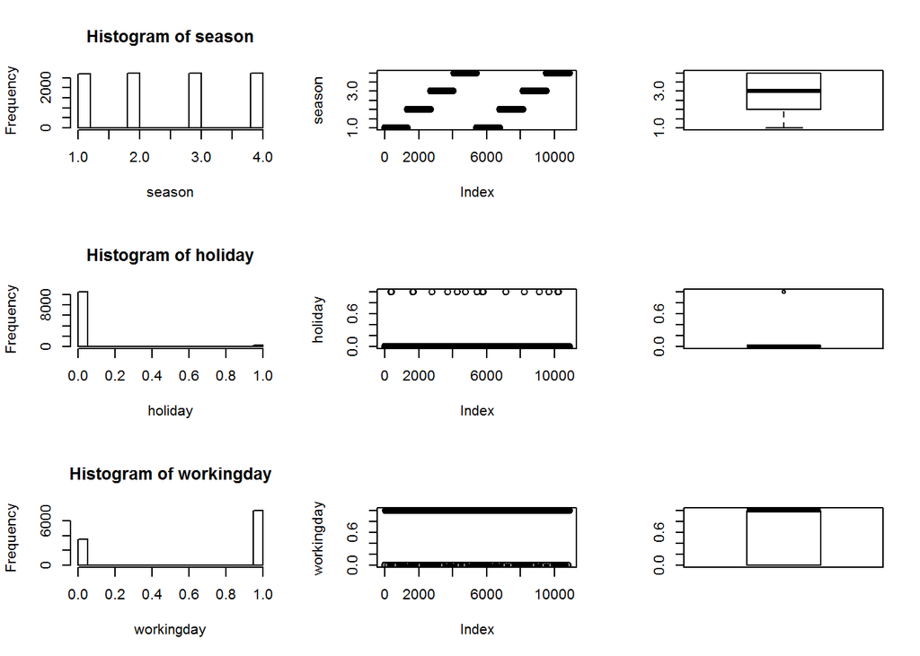

```r
plot(workingday)
boxplot(workingday)
```

```r
par(mfrow = c(3,3))
weather = data.train[,5] # categorical data
hist(weather) # weather
table(weather)
```

```
## weather
##    1    2    3    4
## 7192 2834  859    1
```

```r
plot(weather)
boxplot(weather)
temp = data.train[,6] # continuous data or quantitative data
hist(temp) # temp
table(temp)
```

```
## temp
##  0.82  1.64  2.46  3.28   4.1  4.92  5.74  6.56  7.38   8.2  9.02  9.84
##     7     2     5    11    44    60   107   146   106   229   248   294
## 10.66 11.48  12.3 13.12 13.94 14.76 15.58  16.4 17.22 18.04 18.86 19.68
##   332   181   385   356   413   467   255   400   356   328   406   170
##  20.5 21.32 22.14 22.96 23.78  24.6 25.42 26.24 27.06 27.88  28.7 29.52
##   327   362   403   395   203   390   403   453   394   224   427   353
## 30.34 31.16 31.98  32.8 33.62 34.44 35.26 36.08  36.9 37.72 38.54 39.36
##   299   242    98   202   130    80    76    23    46    34     7     6
##    41
##     1
```

```r
plot(temp)
boxplot(temp)
atemp = data.train[,7] # continous data or quantitative data
hist(atemp) # atemp "feels like"
table(atemp)
```

```
## atemp
##   0.76  1.515  2.275   3.03   3.79  4.545  5.305   6.06   6.82  7.575
##      2      1      7      7     16     11     25     73     63     75
##  8.335   9.09   9.85 10.605 11.365  12.12  12.88 13.635 14.395  15.15
##     63    107    127    166    271    195    247    237    269    338
##  15.91 16.665 17.425  18.18  18.94 19.695 20.455  21.21  21.97 22.725
##    254    381    314    123     45    255    400    356    328    406
## 23.485  24.24     25  25.76 26.515 27.275  28.03  28.79 29.545 30.305
##    170    327    365    423    395    282     80    175    257    350
##  31.06  31.82 32.575 33.335  34.09  34.85 35.605 36.365  37.12  37.88
##    671    299    272    364    224    283    159    123    118     97
## 38.635 39.395  40.15  40.91 41.665 42.425  43.18  43.94 44.695 45.455
##     74     67     45     39     23     24      7      7      3      1
```

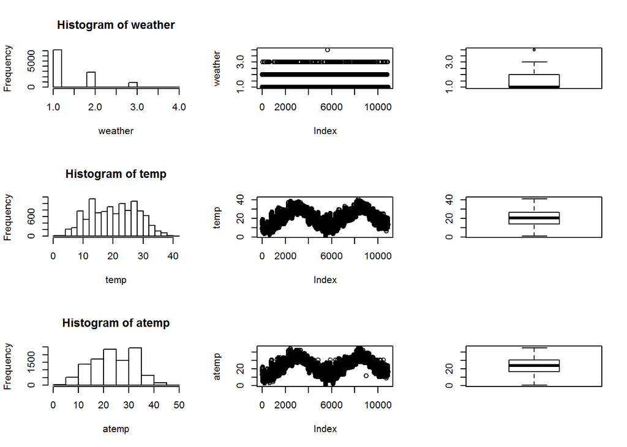

```r
plot(atemp)
boxplot(atemp)
```

```r
par(mfrow = c(3,3))
humidity = data.train[,8] # humidity continuous data or quantitative data
hist(humidity)
table(humidity)
```

```
## humidity
##   0   8  10  12  13  14  15  16  17  18  19  20  21  22  23  24  25  26
##  22   1   1   1   1   2   4   8   6   7  15  10  16  18  37  37  32  39
##  27  28  29  30  31  32  33  34  35  36  37  38  39  40  41  42  43  44
##  49  61  65  60  80  64 104  93 107 129 149 127 126 167 184 133 193 151
##  45  46  47  48  49  50  51  52  53  54  55  56  57  58  59  60  61  62
## 143 247 146 129 234 190 161 218 186 164 224 208 145 168 178 162 205 202
##  63  64  65  66  67  68  69  70  71  72  73  74  75  76  77  78  79  80
## 104 128 253 246 110 131 207 259 107 136 195 197 113 144 244 192 149  60
##  81  82  83  84  85  86  87  88  89  90  91  92  93  94  96  97 100
## 174 200 316  75   4  40 289 368 150   4   1   2 205 324   1   1 148
```

```r
plot(humidity)
boxplot(humidity)
windspeed = data.train[,9] # windspeed continuous data or quantitative data
hist(windspeed)
table(windspeed)
```

```
## windspeed
##       0  6.0032  7.0015  8.9981 11.0014  12.998 15.0013 16.9979 19.0012
##    1313     872    1034    1120    1057    1042     961     824     676
## 19.9995 22.0028 23.9994 26.0027 27.9993 30.0026 31.0009 32.9975 35.0008
##     492     372     274     235     187     111      89      80      58
## 36.9974 39.0007 40.9973 43.0006 43.9989 46.0022 47.9988 50.0021 51.9987
##      22      27      11      12       8       3       2       1       1
## 56.9969
##       2
```

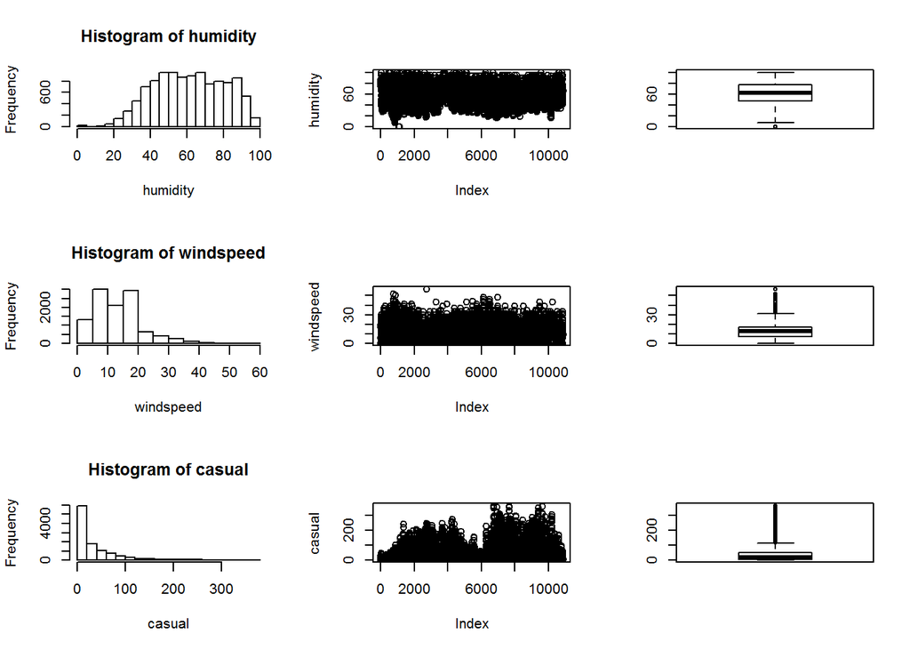

```r
plot(windspeed)
boxplot(windspeed)
casual = data.train[,10] # casual quantitative data looks like long tail
hist(casual)
plot(casual)
boxplot(casual)
```

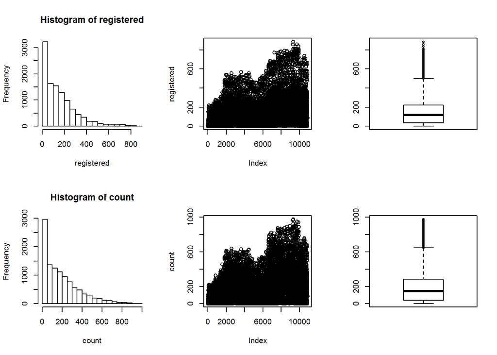

```r
par(mfrow = c(2,3))
registered = data.train[,11] # registered quantitative data long tail
hist(registered)
plot(registered)
boxplot(registered)
count = data.train[,12] # count quantitative data
hist(count)
plot(count)
boxplot(count)
```